##Shrub Density influences on Animals The following is a review of shrubs that have been reported as benefactor species on local animal communities. Web of Science resources were queried using the following key terms.

"facil* density* shrub*”, “density* shrub* facilitate*” and “density* shrub* animal* facil*"

###Questions: Is there evidence that shrub studies that reported facilitation of other plants or of animals influence measures of animal community composition?  
Is there are a relationship between animal abundance or richness and shrub or tree density? Is there a difference between the measures of animal community composition in studies that reported facilitation or not?

###Hypothesis: Higher density of foundation species that have reported facilitation support higher densities or more rich animal communities.

###Predictions: 1. Reported benefactor plants better support animal communities.  
2. Higher density of benefactor plants predict higher measures of animal community structure or composition.

###Good Figures (May 18 2021)

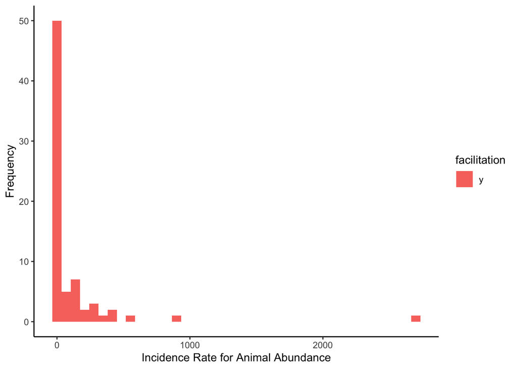

```r
ggplot(data = data_e1, aes(yi, fill = facilitation)) +
  geom_histogram(bins = 40) + labs(x = "Incidence Rate for Animal Abundance", y = "Frequency") + theme_classic()
```

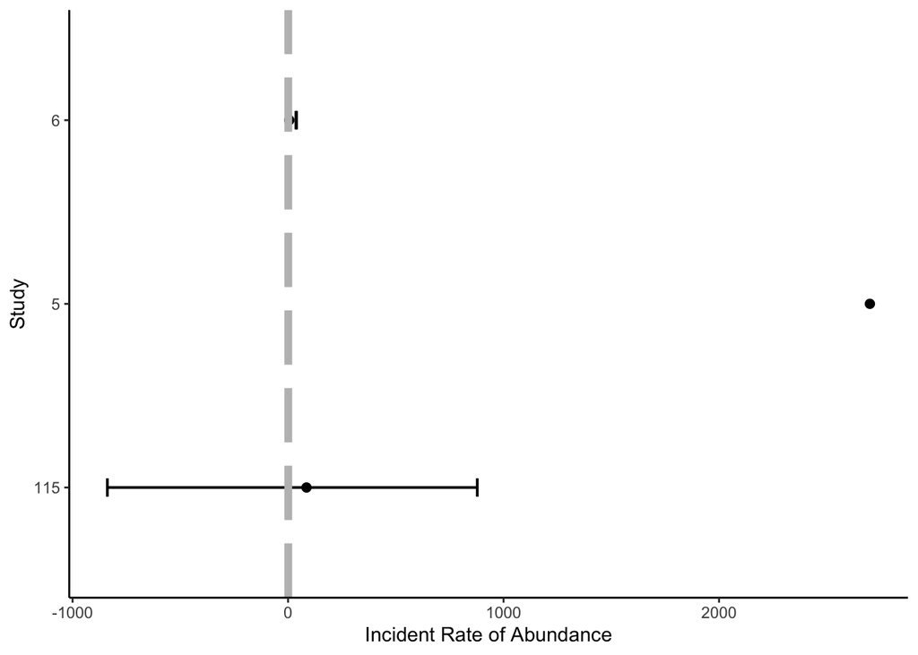

```r
ggplot(summary_data, aes(Study.ID, abundance_rate)) +
  geom_point(size =2) +
  geom_errorbar(aes(ymin = abundance - var_abundance, ymax = abundance + var_abundance), size= 0.7, width=0.1, position = position_dodge(width = 0.5)) +
  coord_flip() +
  geom_hline(yintercept = 1, colour="grey", linetype = "longdash", size = 2) +
  labs(x = "Study", y = "Incident Rate of Abundance") + theme_classic()
```

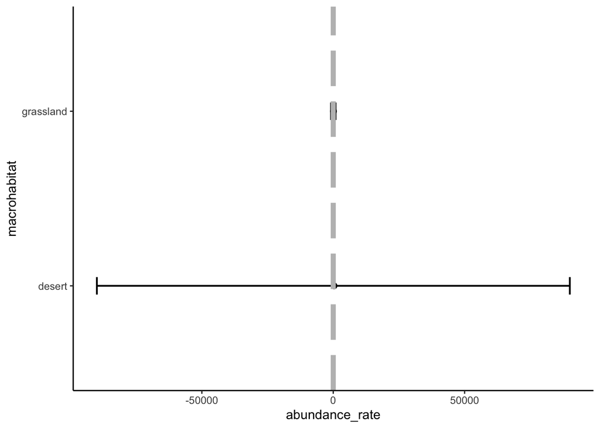

```r
ggplot(summary_data2, aes(macrohabitat, abundance_rate)) +
  geom_point(size =2) +
  geom_errorbar(aes(ymin = abundance - var_abundance, ymax = abundance + var_abundance), size= 0.7, width=0.1, position = position_dodge(width = 0.5)) +
  coord_flip() +
  geom_hline(yintercept = 1, colour="grey", linetype = "longdash", size = 2) + theme_classic()
```

###Meta Models

```r
library(broom)
#x = density
#y = abundance
#With density
mod1.1 <- rma(yi = yi, sei = vi, method = "ML", mods = ~standardized.density, test = "knha", control=list(stepadj=0.5), data = data_e1)
summary(mod1.1)
```

```
##
## Mixed-Effects Model (k = 73; tau^2 estimator: ML)
##
##    logLik   deviance        AIC        BIC       AICc
## -371.9418    11.7913   749.8836   756.7550   750.2314
##
## tau^2 (estimated amount of residual heterogeneity):     0 (SE = 0.0621)
## tau (square root of estimated tau^2 value):             0
## I^2 (residual heterogeneity / unaccounted variability): 0.00%
## H^2 (unaccounted variability / sampling variability):   1.00
## R^2 (amount of heterogeneity accounted for):            100.00%
##
## Test for Residual Heterogeneity:
## QE(df = 71) = 11.7913, p-val = 1.0000
##
## Test of Moderators (coefficient 2):
## F(df1 = 1, df2 = 71) = 135.7857, p-val < .0001
##
## Model Results:
##
##                       estimate      se      tval    pval    ci.lb    ci.ub
## intrcpt                 7.2419  0.3187   22.7256  <.0001   6.6065   7.8773  ***
## standardized.density   -0.3331  0.0286  -11.6527  <.0001  -0.3901  -0.2761  ***
##
## ---
## Signif. codes:  0 '***' 0.001 '**' 0.01 '*' 0.05 '.' 0.1 ' ' 1
```

```r
m1.1 <- tidy(mod1.1)
m1.1
```

```
## # A tibble: 2 x 6
##   term                 type    estimate std.error statistic  p.value
##   <chr>                <chr>      <dbl>     <dbl>     <dbl>    <dbl>
## 1 intercept            summary    7.24     0.319       22.7 2.65e-34
## 2 standardized.density summary   -0.333    0.0286     -11.7 3.82e-18
```

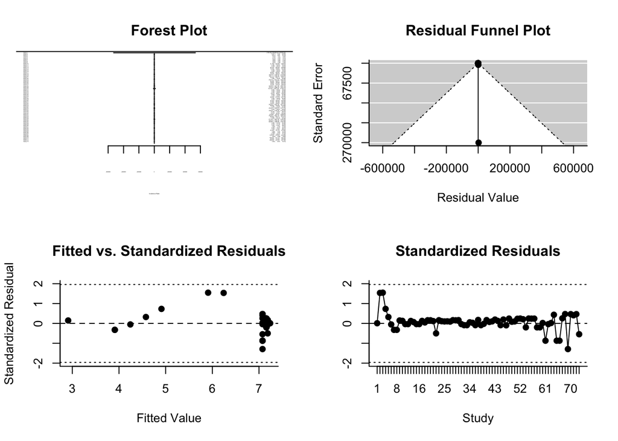

```r
plot(mod1.1)
```

###EDA

```r
#With Ecosystem (Not usefull)
mod1.2 <- rma(yi = yi, sei = vi, method = "ML", mods = ~macrohabitat -1, test = "knha", control=list(stepadj=0.5), data = data_e1)
summary(mod1.2)
```

```
##
## Mixed-Effects Model (k = 73; tau^2 estimator: ML)
##
##    logLik   deviance        AIC        BIC       AICc
## -378.4286    24.7649   762.8572   769.7286   763.2050
##
## tau^2 (estimated amount of residual heterogeneity):     0.4529 (SE = 0.3748)
## tau (square root of estimated tau^2 value):             0.6730
## I^2 (residual heterogeneity / unaccounted variability): 16.53%
## H^2 (unaccounted variability / sampling variability):   1.20
##
## Test for Residual Heterogeneity:
## QE(df = 71) = 34.3148, p-val = 0.9999
##
## Test of Moderators (coefficients 1:2):
## F(df1 = 2, df2 = 71) = 335.8655, p-val < .0001
##
## Model Results:
##
##                        estimate      se     tval    pval   ci.lb   ci.ub
## macrohabitatdesert       4.1283  0.1606  25.7014  <.0001  3.8080  4.4486  ***
## macrohabitatgrassland    3.2846  0.9829   3.3417  0.0013  1.3247  5.2444   **
##
## ---
## Signif. codes:  0 '***' 0.001 '**' 0.01 '*' 0.05 '.' 0.1 ' ' 1
```

```r
m1.2 <- tidy(mod1.2)
m1.2
```

```
## # A tibble: 2 x 6
##   term                  type    estimate std.error statistic  p.value
##   <chr>                 <chr>      <dbl>     <dbl>     <dbl>    <dbl>
## 1 macrohabitatdesert    summary     4.13     0.161     25.7  1.08e-37
## 2 macrohabitatgrassland summary     3.28     0.983      3.34 1.33e- 3
```

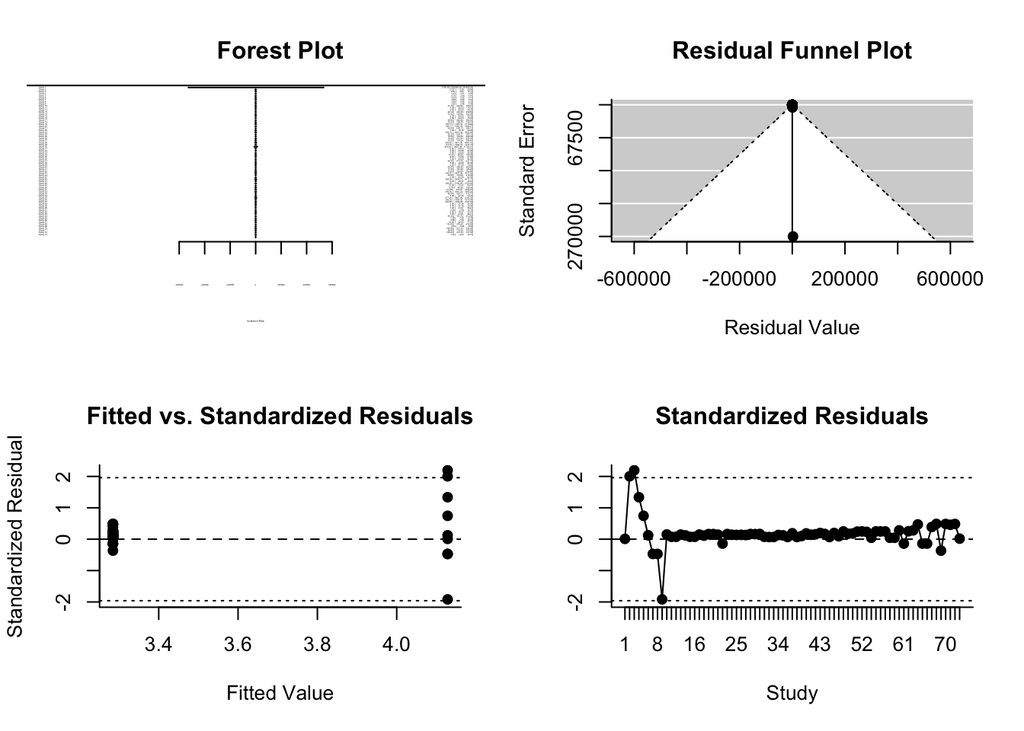

```r
plot(mod1.2)
```

```r
#Without data and ecosystem
mod1.3 <- rma(yi = yi, sei = vi, method = "ML", test = "knha", control=list(stepadj=0.5), data = data_e1)
summary(mod1.3)
```

```
##
## Random-Effects Model (k = 73; tau^2 estimator: ML)
##
##    logLik   deviance        AIC        BIC       AICc
## -378.5135    24.9347   761.0271   765.6080   761.1985
##
## tau^2 (estimated amount of total heterogeneity): 0.4399 (SE = 0.3668)
## tau (square root of estimated tau^2 value):      0.6632
## I^2 (total heterogeneity / total variability):   15.98%
## H^2 (total variability / sampling variability):  1.19
##
## Test for Heterogeneity:
## Q(df = 72) = 34.3419, p-val = 1.0000
##
## Model Results:
##
## estimate      se     tval    pval   ci.lb   ci.ub
##   4.1011  0.1572  26.0855  <.0001  3.7877  4.4145  ***
##
## ---
## Signif. codes:  0 '***' 0.001 '**' 0.01 '*' 0.05 '.' 0.1 ' ' 1
```

```r
ml.3 <- tidy(mod1.3)
ml.3
```

```
## # A tibble: 1 x 6
##   term    type    estimate std.error statistic  p.value
##   <chr>   <chr>      <dbl>     <dbl>     <dbl>    <dbl>
## 1 overall summary     4.10     0.157      26.1 2.01e-38
```

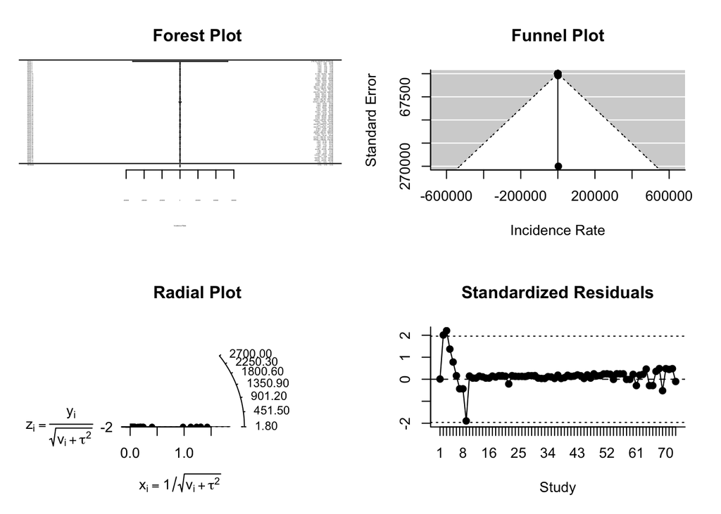

```r
plot(mod1.3)
```

###Data Viz

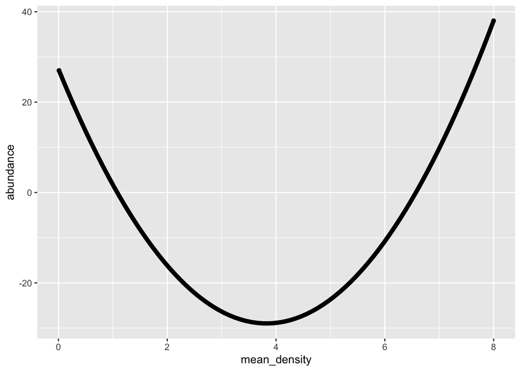

```r
##Mean Density by abundance
ggplot(summary_data, aes(mean_density, abundance)) +
  geom_point() +
  stat_smooth(method = "lm", formula = y ~ x + I(x^2), size = 2, color = "black", size = 2, se = FALSE)
```

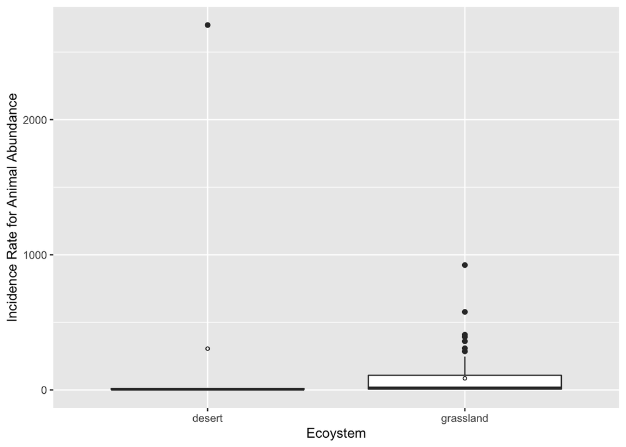

```r
###Abundance by ecosystem (Does not seem important for us)
ggplot(data_e1, aes(macrohabitat, yi)) +
  geom_boxplot() +
  labs(x = "Ecoystem", y = "Incidence Rate for Animal Abundance") +
  stat_summary(fun.y=mean, geom="point", shape=1, size = 1, color="black", fill="red")
```

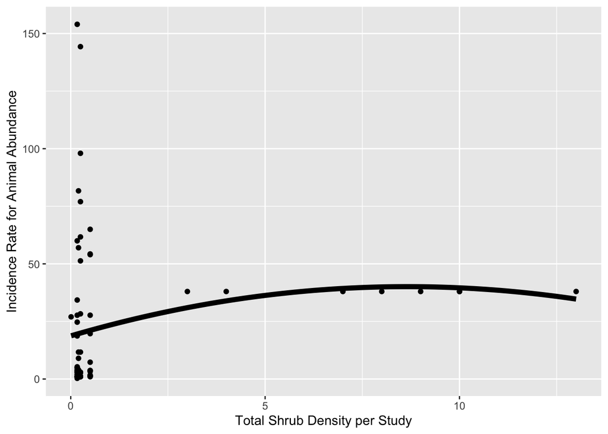

```r
##Standardized density by animal abundance
ggplot(data_e1, aes(standardized.density, abundance)) +
  geom_point() +
  stat_smooth(method = "lm", formula = y ~ x + I(x^2), size = 2, color = "black", se = FALSE) +
  labs(x = "Total Shrub Density per Study", y = "Incidence Rate for Animal Abundance")
```

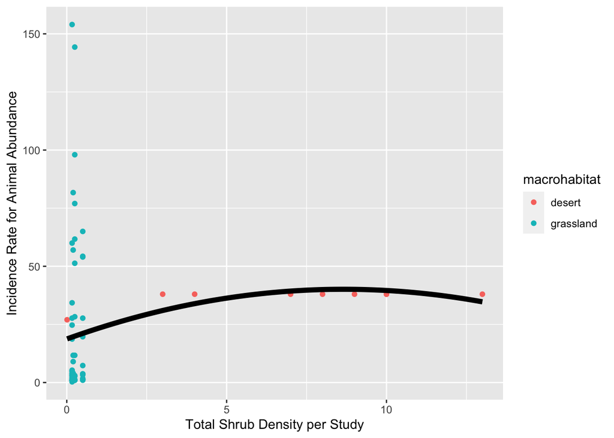

```r
##Standardized density by animal abundance groupped by ecosystem
ggplot(data_e1, aes(standardized.density, abundance)) +
  geom_point(aes(color = macrohabitat)) +
  stat_smooth(method = "lm", formula = y ~ x + I(x^2), size = 2, color = "black", se = FALSE) +
  labs(x = "Total Shrub Density per Study", y = "Incidence Rate for Animal Abundance")
```

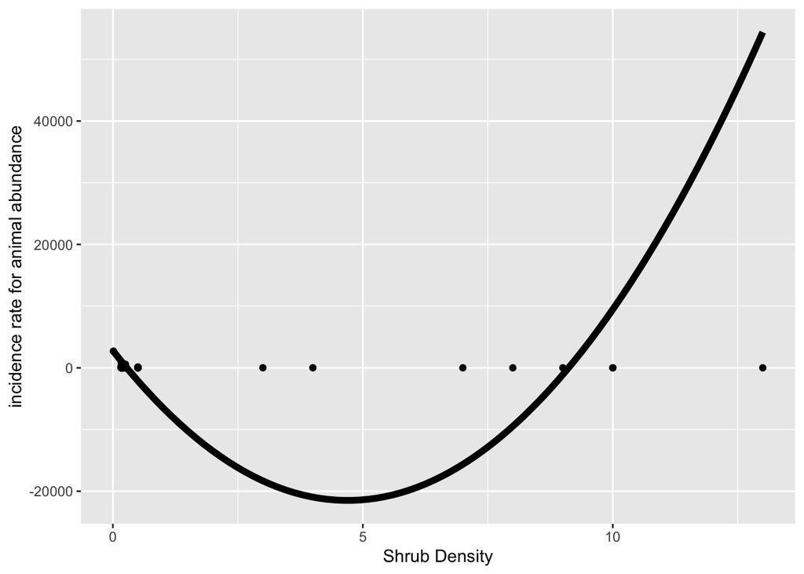

```r
ggplot(data_e1, aes(standardized.density, yi, weight = vi)) +
  geom_point() +
  stat_smooth(method = "lm", formula = y ~ x + I(x^2), size = 2, color = "black", size = 2, se = FALSE) +
  labs(x = "Shrub Density", y = "incidence rate for animal abundance")
```

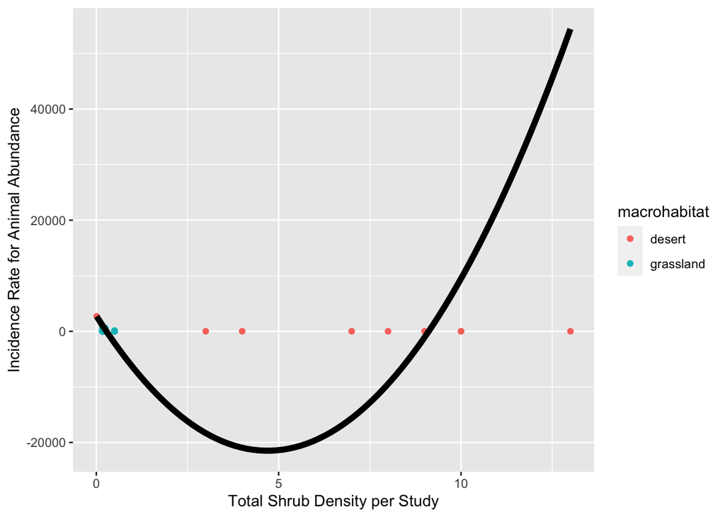

```r
ggplot(data_e1, aes(standardized.density, yi, weight = vi)) +
  geom_point(aes(color = macrohabitat)) +
  stat_smooth(method = "lm", formula = y ~ x + I(x^2), size = 2, color = "black", size = 2, se = FALSE) +
  labs(x = "Total Shrub Density per Study", y = "Incidence Rate for Animal Abundance")
```

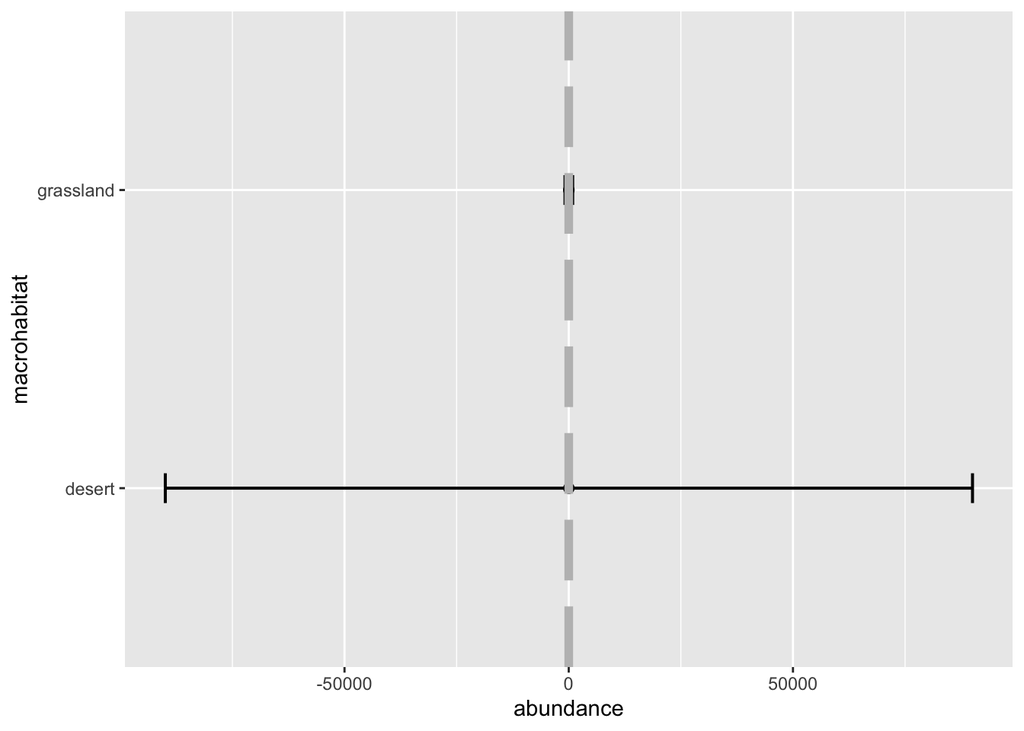

```r
ggplot(summary_data2, aes(macrohabitat, abundance)) +
  geom_point(size =2) +
  geom_errorbar(aes(ymin = abundance - var_abundance, ymax = abundance + var_abundance), size= 0.7, width=0.1, position = position_dodge(width = 0.5)) +
  coord_flip() +
  geom_hline(yintercept = 1, colour="grey", linetype = "longdash", size = 2)
```